# Project H

Cathy Liu, Qinzhi Peng

2022-06-26

### Abstract

This project analyzes suggestions to upper management posted by employees from a large human resource company, in order to figure out which suggestions are recommended to follow up upon. The data set is from the online forum of the human resource company. And our report has the following sections:

- Introduction
- Exploratory Data Analysis
- Variable Selection
- Model Comparison and Selection
- Analysis
- Conclusion and Further Work
- Our Takeaway from this Project
- Reference

### Introduction

This project is a classic binary classification problem. There are around 16,000 suggestions in the data set and different suggestions are labeled in either 1(recommended) or 0(not recommended). Other information provided include number of posts(suggestions), responses, views, Votes_Up, Votes_Down, as well as author information, including number of days authors have been with the company, their total posts and posts per day.

In this project, we will explore several different models, e.g., logistic regression, LDA, trees and etc., and will evaluate their performances using methods such as cross validation and confusion matrix. With the help of the models, we are hoping to find out the best combination of attributes that make a ‘good’ suggestion, and hopefully gain some insights into this project.

### Exploratory Data Anaylsis

In this session, we explore the data to better understand its structure and relationship. Before we start the analysis, we need to upload the libraries.

```r
# load libraries
library(gbm)
library(rpart)
library(partykit)
library(ggplot2)
library(ISLR)
library(MASS)
library(klaR)
library(knitr)
library(glmnet)
library(plyr)
library(gam)
library(readxl)
library(caret)
library(pROC)
library(dplyr)
library(magrittr)
```

First, let us take a look at the first few rows of, as well as the structure of the data.

```r
# read excel file and convert it to data frame
suggest <- read_excel('suggestions.csv.xlsx')
suggest <- data.frame(suggest)

# print first five rows of the excel file and the structure of the data
head(suggest)
```

```
##   Recommended Suggestion_Id Responses Views Votes_Up Votes_Down Author_Id
## 1           0         35463        77  3849      242          7      4886
## 2           0         37480       428 28290     1149        201      3654
## 3           0         39814       160  7561      648         45    113401
## 4           0         41970        89  9937      197         14      8331
## 5           1         47967        12  6977        0          0     13980
## 6           1         50219        62  1608      121         13    144806
##   Author_Join..in.terms.of.how.many.days.since.they.joined. Author_TotalPosts
## 1                                                      1615              8977
## 2                                                      1617              2543
## 3                                                      1385              1003
## 4                                                      1601               223
## 5                                                      1593              3978
## 6                                                      1373                66
##   Author_PostsPerDay
## 1                5.6
## 2                1.6
## 3                0.7
## 4                0.1
## 5                2.5
## 6                0.0
```

```r
str(suggest)
```

```
## 'data.frame':    16429 obs. of  10 variables:
##  $ Recommended                                              : num  0 0 0 0 1 1 1 0 0 0 ...
##  $ Suggestion_Id                                            : num  35463 37480 39814 41970 47967 ...
##  $ Responses                                                : num  77 428 160 89 12 62 11 0 169 0 ...
##  $ Views                                                    : num  3849 28290 7561 9937 6977 ...
##  $ Votes_Up                                                 : num  242 1149 648 197 0 ...
##  $ Votes_Down                                               : num  7 201 45 14 0 13 0 11 30 8 ...
##  $ Author_Id                                                : num  4886 3654 113401 8331 13980 ...
##  $ Author_Join..in.terms.of.how.many.days.since.they.joined.: num  1615 1617 1385 1601 1593 ...
##  $ Author_TotalPosts                                        : num  8977 2543 1003 223 3978 ...
##  $ Author_PostsPerDay                                       : num  5.6 1.6 0.7 0.1 2.5 0 1.6 0 0.4 0.3 ...
```

From the table below, we can tell that the recommended topics to follow up from the data is 562, compared to 15,867 non-recommended topics. And since one of the column names is too long, we rename that column as a matter of convenience.

```r
# get a table of number of Recommended vs non-recommended
with(suggest, table(Recommended, Recommended))
```

```
##            Recommended
## Recommended     0     1
##           0 15867     0
##           1     0   562
```

```r
nrow(suggest)
```

```
## [1] 16429
```

```r
# rename a column
names(suggest)[names(suggest) == "Author_Join..in.terms.of.how.many.days.since.they.joined."] <- "Author_JoinDays"

# remove columns: Suggestion_Id and Author_Id from our data set
suggest.subset <- suggest[, c('Recommended', 'Responses', 'Views', 'Votes_Up', 'Votes_Down', 'Author_JoinDays',
                              'Author_TotalPosts', 'Author_PostsPerDay')]

# split training set and test set
set.seed(1)
split <- sample(1:nrow(suggest.subset),round(nrow(suggest.subset)*2/3))
train <- suggest.subset[split,]
test <- suggest.subset[-split,]

# Extract covariates matrix and  response variable (for lasso)
suggest.x <- as.matrix(suggest.subset[, -which(names(suggest.subset) == "Recommended")])
suggest.y <- suggest.subset$Recommended
```

From the data set, we know that the number of good suggestions is much less than the number of bad suggestions. Next, we want to see the relationship between Votes_Up and Votes_Down. From the plot below, it seems these two variables are correlated.

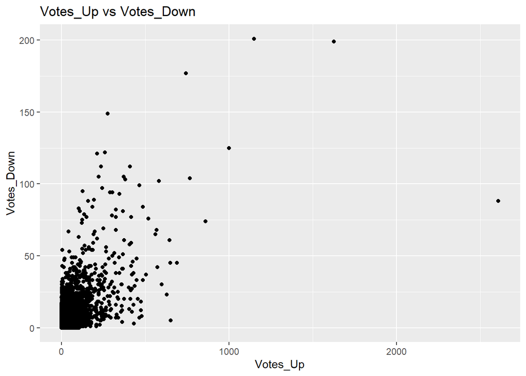

```r
# plot Votes_Down as a function of Votes_Up
ggplot(data = suggest, mapping = aes(x = Votes_Up, y = Votes_Down)) +
  geom_point() +
  labs(title = "Votes_Up vs Votes_Down")
```

And there is an outlier from the plot, with Votes_Up more than 2000 but relatively much less Votes_Down. We pull out the data below. Even though it looks like an outlier, but it may be just because this suggestion is highly recommended by employees.

```r
# get the outlier
suggest[suggest$Votes_Up > 2000, ]
```

```
##      Recommended Suggestion_Id Responses Views Votes_Up Votes_Down Author_Id
## 1008           1        127554       959 44039     2607         88    306610
##      Author_JoinDays Author_TotalPosts Author_PostsPerDay
## 1008            1280               884                0.7
```

Below is another plot showing the relationship between Author_PostsPerDay and Author_TotalPosts. These two variables may be correlated as well. There is an outlier, which has Author_PostsPerDay larger than 20. We pulled out the data and found out it is a calculation error, so we removed this outlier.

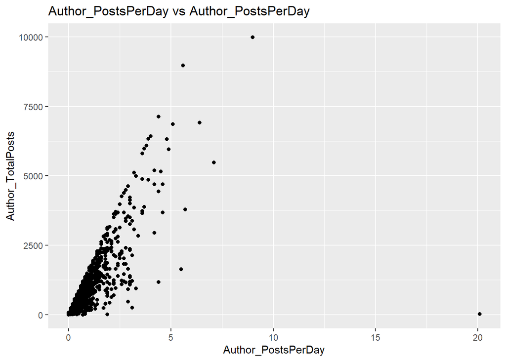

```r
ggplot(data = suggest, mapping = aes(x = Author_PostsPerDay , y = Author_TotalPosts)) +
  geom_point() +
  labs(title = "Author_PostsPerDay vs Author_PostsPerDay")
```

```r
# get the outlier and delete it
suggest[suggest$Author_PostsPerDay > 20, ]
```

```
##       Recommended Suggestion_Id Responses Views Votes_Up Votes_Down Author_Id
## 16426           0        300415        14   251        0          0   1500210
##       Author_JoinDays Author_TotalPosts Author_PostsPerDay
## 16426               4                26               20.1
```

```r
# remove the outlier
suggest <- suggest[suggest$Author_PostsPerDay < 20, ]
suggest.subset <- suggest.subset[suggest.subset$Author_PostsPerDay < 20, ]
```

We want to figure out if any the features are highly correlated, and if they are, in order to achieve better results, we may need to drop the redundant features in some of the models we fit, i.e. in logistic regression.

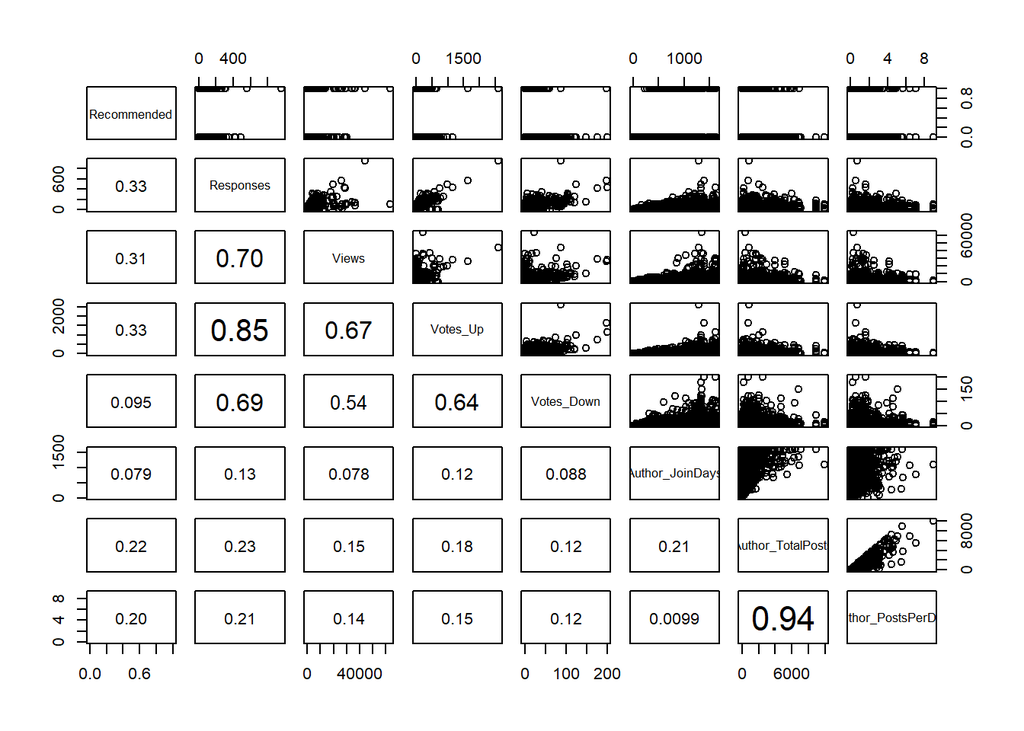

```r
# correlation function from homework 1
panel.cor <- function(x, y, digits = 2, prefix = "", cex.cor, ...)
{
    usr <- par("usr"); on.exit(par(usr))
    par(usr = c(0, 1, 0, 1))
    r <- abs(cor(x, y))
    txt <- format(c(r, 0.123456789), digits = digits)[1]
    txt <- paste0(prefix, txt)
    if(missing(cex.cor)) cex.cor <- 0.8/strwidth(txt)
    text(0.5, 0.5, txt, cex = pmax(1, cex.cor * r))
}

# get a plot matrix for the collinearity analysis
pairs(suggest.subset, lower.panel = panel.cor)
```

We can see `Responses` `Views`, `Votes_Up`, and `Votes_Down` are highly correlated, `Author_PostsPerDay`and `Author_TotalPosts` are highly correlated.

### Variables Selection

First, we use lasso method to find the optimal value of lambda that minimizes the cross-validation error.

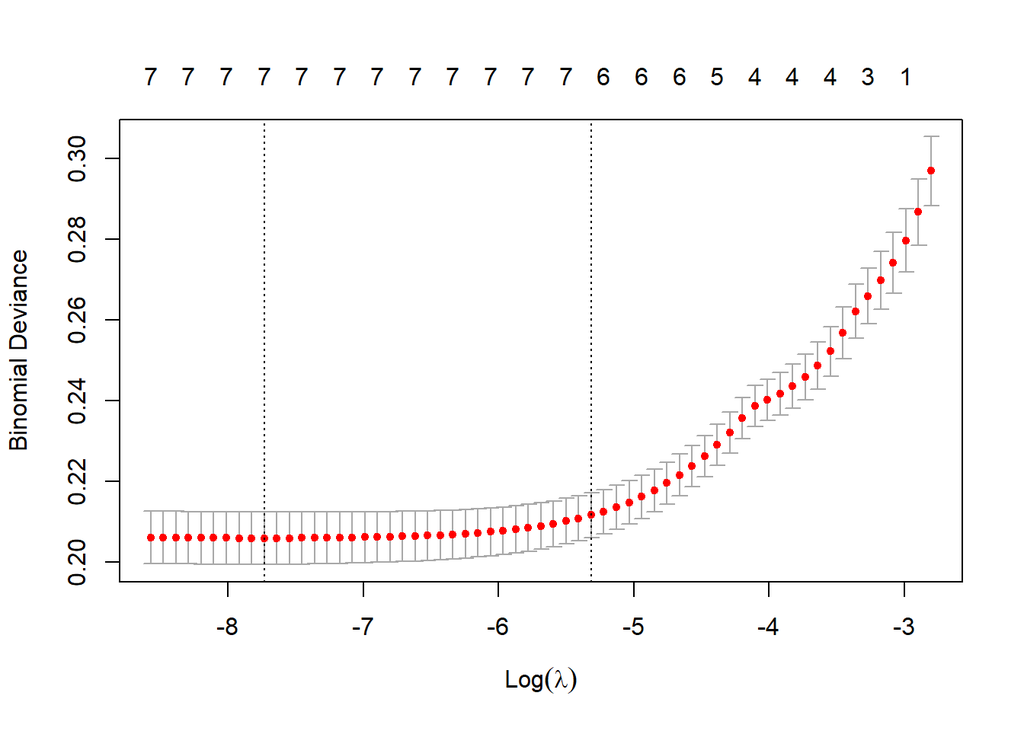

```r
set.seed(1)
suggest.lasso.cv <- cv.glmnet(suggest.x, suggest.y, family = "binomial")
plot(suggest.lasso.cv)
```

The plot displays the cross-validation error according to the log of lambda. The left vertical line shows that the log of the optimal value of lambda is approximately -8, which minimizes the prediction error. This lambda value will give the most accurate model. The optimal value is:

```r
suggest.lasso.cv$lambda.min
```

```
## [1] 0.0004381808
```

Using the min-CV rule, we get the following regression coefficients:

```r
coef(suggest.lasso.cv, s = "lambda.min")
```

```
## 8 x 1 sparse Matrix of class "dgCMatrix"
##                               s1
## (Intercept)        -5.230629e+00
## Responses           2.831853e-02
## Views               1.921803e-04
## Votes_Up            1.182581e-02
## Votes_Down         -1.513204e-01
## Author_JoinDays     6.812038e-04
## Author_TotalPosts   4.525531e-05
## Author_PostsPerDay  3.483738e-01
```

Using the 1-SE rule, This lambda’s value is:

```r
suggest.lasso.cv$lambda.1se
```

```
## [1] 0.00492219
```

Using the 1-SE rule, we get the following regression coefficients:

```r
coef(suggest.lasso.cv, s = "lambda.1se")
```

```
## 8 x 1 sparse Matrix of class "dgCMatrix"
##                               s1
## (Intercept)        -4.3197580940
## Responses           0.0234226043
## Views               0.0001224178
## Votes_Up            0.0077917186
## Votes_Down         -0.0848766346
## Author_JoinDays     .
## Author_TotalPosts   0.0002238458
## Author_PostsPerDay  0.1192359136
```

```r
# use min-CV rule
suggest.lasso.cv$cvm[suggest.lasso.cv$lambda == suggest.lasso.cv$lambda.min]
```

```
## [1] 0.2058924
```

```r
# use 1SE rule
suggest.lasso.cv$cvm[suggest.lasso.cv$lambda == suggest.lasso.cv$lambda.1se]
```

```
## [1] 0.2115998
```

Although the CV error of the lambda.1se model is a bit larger than what we got using lambda.min in the lasso regression, it looks like the model with a small number of predictors does as good a job of prediction.

### Model Comparison and Selection

#### Logistic Regression

First, we fit the model using all variable:

```r
suggest.full <- glm(Recommended ~., data = train, family = 'binomial')
summary(suggest.full)
```

```
##
## Call:
## glm(formula = Recommended ~ ., family = "binomial", data = train)
##
## Deviance Residuals:
##     Min       1Q   Median       3Q      Max
## -4.5045  -0.1943  -0.1569  -0.1264   4.2252
##
## Coefficients:
##                      Estimate Std. Error z value Pr(>|z|)
## (Intercept)        -5.356e+00  2.870e-01 -18.666  < 2e-16 ***
## Responses           2.984e-02  2.995e-03   9.963  < 2e-16 ***
## Views               2.327e-04  3.764e-05   6.183 6.30e-10 ***
## Votes_Up            1.284e-02  1.612e-03   7.965 1.65e-15 ***
## Votes_Down         -1.765e-01  1.366e-02 -12.919  < 2e-16 ***
## Author_JoinDays     7.775e-04  2.431e-04   3.198  0.00139 **
## Author_TotalPosts   4.054e-05  1.024e-04   0.396  0.69230
## Author_PostsPerDay  3.527e-01  1.147e-01   3.074  0.00211 **
## ---
## Signif. codes:  0 '***' 0.001 '**' 0.01 '*' 0.05 '.' 0.1 ' ' 1
##
## (Dispersion parameter for binomial family taken to be 1)
##
##     Null deviance: 3254.5  on 10952  degrees of freedom
## Residual deviance: 2217.2  on 10945  degrees of freedom
## AIC: 2233.2
##
## Number of Fisher Scoring iterations: 7
```

```r
set.seed(1)
suggest.glm <- glm(Recommended ~ Responses + Views + Votes_Up + Votes_Down + Author_JoinDays + Author_PostsPerDay, data = train, family = 'binomial')
summary(suggest.glm)
```

```
##
## Call:
## glm(formula = Recommended ~ Responses + Views + Votes_Up + Votes_Down +
##     Author_JoinDays + Author_PostsPerDay, family = "binomial",
##     data = train)
##
## Deviance Residuals:
##     Min       1Q   Median       3Q      Max
## -4.4992  -0.1953  -0.1570  -0.1256   4.2324
##
## Coefficients:
##                      Estimate Std. Error z value Pr(>|z|)
## (Intercept)        -5.417e+00  2.441e-01 -22.191  < 2e-16 ***
## Responses           2.985e-02  2.995e-03   9.966  < 2e-16 ***
## Views               2.329e-04  3.765e-05   6.188 6.11e-10 ***
## Votes_Up            1.282e-02  1.611e-03   7.960 1.73e-15 ***
## Votes_Down         -1.765e-01  1.366e-02 -12.924  < 2e-16 ***
## Author_JoinDays     8.330e-04  1.980e-04   4.208 2.58e-05 ***
## Author_PostsPerDay  3.966e-01  3.338e-02  11.881  < 2e-16 ***
## ---
## Signif. codes:  0 '***' 0.001 '**' 0.01 '*' 0.05 '.' 0.1 ' ' 1
##
## (Dispersion parameter for binomial family taken to be 1)
##
##     Null deviance: 3254.5  on 10952  degrees of freedom
## Residual deviance: 2217.4  on 10946  degrees of freedom
## AIC: 2231.4
##
## Number of Fisher Scoring iterations: 7
```

We then evaluate our model below.

```r
# prediction based on the logistic model fitted above
prob.glm <- predict(suggest.glm, newdata = test, type = 'response')
pred.glm <- ifelse(prob.glm > 0.5, 1, 0)

# get the confusion matrix
tab.glm <- confusionMatrix(as.factor(test$Recommended), as.factor(pred.glm), positive = "1")
tab.glm
```

```
## Confusion Matrix and Statistics
##
##           Reference
## Prediction    0    1
##          0 5248   39
##          1  155   34
##
##                Accuracy : 0.9646
##                  95% CI : (0.9593, 0.9693)
##     No Information Rate : 0.9867
##     P-Value [Acc > NIR] : 1
##
##                   Kappa : 0.245
##
##  Mcnemar's Test P-Value : <2e-16
##
##             Sensitivity : 0.465753
##             Specificity : 0.971312
##          Pos Pred Value : 0.179894
##          Neg Pred Value : 0.992623
##              Prevalence : 0.013331
##          Detection Rate : 0.006209
##    Detection Prevalence : 0.034514
##       Balanced Accuracy : 0.718533
##
##        'Positive' Class : 1
##
```

```r
# ROC curve
roc.glm <- roc(as.factor(test$Recommended), prob.glm)
```

#### Additive Logistic Regression

```r
set.seed(1)
suggest.gam <- gam(Recommended ~  s(Responses, 4) + s(Views, 4) + s(Votes_Up, 4) + s(Votes_Down, 4) + s(Author_PostsPerDay, 4), data = train)
par(mfrow=c(3,2))
# display the fitted splines for each term
plot(suggest.gam, col="ForestGreen")

prob.gam <- predict(suggest.gam, newdata=test, type="response")
pred.gam <- ifelse(prob.gam > 0.5, 1, 0)

# confusion matrix
tab.gam <- confusionMatrix(as.factor(pred.gam), as.factor(test$Recommended), positive = "1")
tab.gam
```

```
## Confusion Matrix and Statistics
##
##           Reference
## Prediction    0    1
##          0 5260  160
##          1   27   29
##
##                Accuracy : 0.9659
##                  95% CI : (0.9607, 0.9705)
##     No Information Rate : 0.9655
##     P-Value [Acc > NIR] : 0.4603
##
##                   Kappa : 0.2245
##
##  Mcnemar's Test P-Value : <2e-16
##
##             Sensitivity : 0.153439
##             Specificity : 0.994893
##          Pos Pred Value : 0.517857
##          Neg Pred Value : 0.970480
##              Prevalence : 0.034514
##          Detection Rate : 0.005296
##    Detection Prevalence : 0.010226
##       Balanced Accuracy : 0.574166
##
##        'Positive' Class : 1
##
```

[figure not shown]

```r
# ROC curve
roc.gam <- roc(test$Recommended, prob.gam)
```

We can see the Additive Logistic model has higher accuracy and Specificity than the normal Logistic model, but it has lower sensitivity. That means in this model we have lower chance to regard a ‘bad’ suggestion as a good one, which is better than the normal Logistic model since what we hate more is when a bad suggestion is mixed with those good suggestions.

#### Naive Bayes

We also run the Naive Bayes, and it turned out to perform a little worse than the model we have run above.

```r
suggest.nb <- NaiveBayes(factor(Recommended) ~ ., data = train, usekernel=TRUE)
pred.nb <- predict(suggest.nb, test, type="response")

# confusion matrix
tab.nb <- confusionMatrix(as.factor(pred.nb$class), as.factor(test$Recommended), positive = "1")
tab.nb
```

```
## Confusion Matrix and Statistics
##
##           Reference
## Prediction    0    1
##          0 4845   48
##          1  442  141
##
##                Accuracy : 0.9105
##                  95% CI : (0.9026, 0.9179)
##     No Information Rate : 0.9655
##     P-Value [Acc > NIR] : 1
##
##                   Kappa : 0.3304
##
##  Mcnemar's Test P-Value : <2e-16
##
##             Sensitivity : 0.74603
##             Specificity : 0.91640
##          Pos Pred Value : 0.24185
##          Neg Pred Value : 0.99019
##              Prevalence : 0.03451
##          Detection Rate : 0.02575
##    Detection Prevalence : 0.10646
##       Balanced Accuracy : 0.83122
##
##        'Positive' Class : 1
##
```

```r
# ROC curve
roc.nb <- roc(test$Recommended, pred.nb$posterior[,1])
```

#### LDA

We run a linear discriminant analysis and quadratic discriminant analysis below.

```r
suggest.lda <- lda(Recommended ~ ., train)
pred.lda <- predict(suggest.lda, test, type="response")

# confusion matrix
tab.lda <- confusionMatrix(as.factor(pred.lda$class), as.factor(test$Recommended), positive = "1")
tab.lda
```

```
## Confusion Matrix and Statistics
##
##           Reference
## Prediction    0    1
##          0 5191  120
##          1   96   69
##
##                Accuracy : 0.9606
##                  95% CI : (0.9551, 0.9656)
##     No Information Rate : 0.9655
##     P-Value [Acc > NIR] : 0.9774
##
##                   Kappa : 0.3695
##
##  Mcnemar's Test P-Value : 0.1176
##
##             Sensitivity : 0.36508
##             Specificity : 0.98184
##          Pos Pred Value : 0.41818
##          Neg Pred Value : 0.97741
##              Prevalence : 0.03451
##          Detection Rate : 0.01260
##    Detection Prevalence : 0.03013
##       Balanced Accuracy : 0.67346
##
##        'Positive' Class : 1
##
```

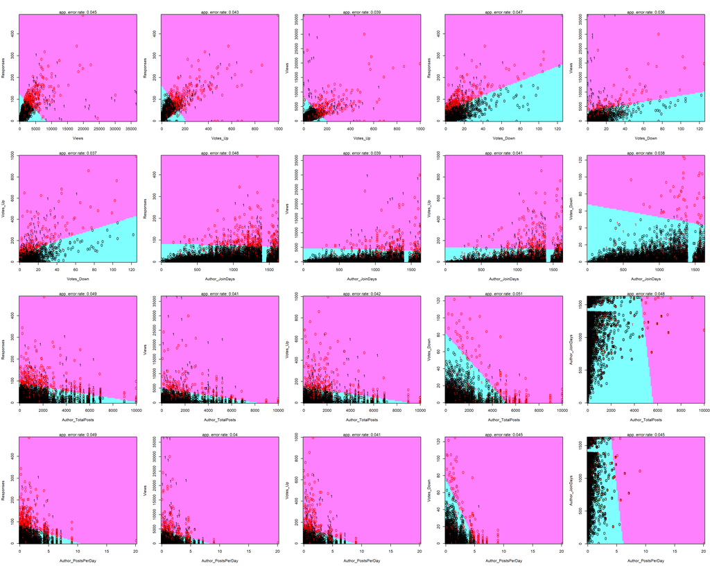

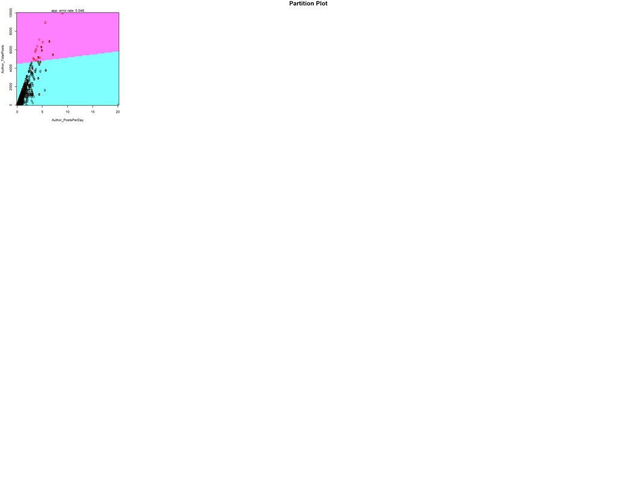

```r
# get bivariate plots showing the LDA decision boundaries
partimat(factor(Recommended) ~ ., data = train, method = "lda")
```

```r
# ROC curve
roc.lda <- roc(as.factor(test$Recommended), pred.lda$posterior[,2])
```

#### QDA

```r
suggest.qda <- qda(Recommended ~ ., data = train)
pred.qda <- predict(suggest.qda, test, type="response")

# confusion matrix
tab.qda <- confusionMatrix(as.factor(pred.qda$class), as.factor(test$Recommended), positive = "1")
tab.qda
```

```
## Confusion Matrix and Statistics
##
##           Reference
## Prediction    0    1
##          0 5051  100
##          1  236   89
##
##                Accuracy : 0.9386
##                  95% CI : (0.932, 0.9449)
##     No Information Rate : 0.9655
##     P-Value [Acc > NIR] : 1
##
##                   Kappa : 0.3165
##
##  Mcnemar's Test P-Value : 1.773e-13
##
##             Sensitivity : 0.47090
##             Specificity : 0.95536
##          Pos Pred Value : 0.27385
##          Neg Pred Value : 0.98059
##              Prevalence : 0.03451
##          Detection Rate : 0.01625
##    Detection Prevalence : 0.05935
##       Balanced Accuracy : 0.71313
##
##        'Positive' Class : 1
##
```

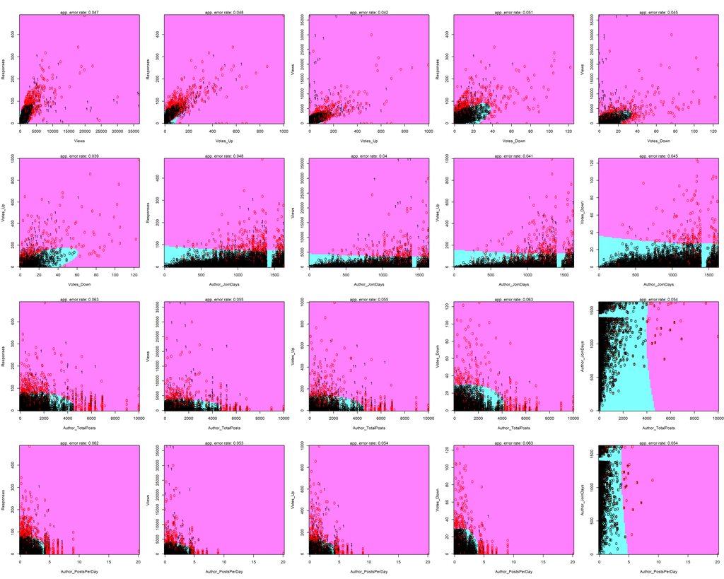

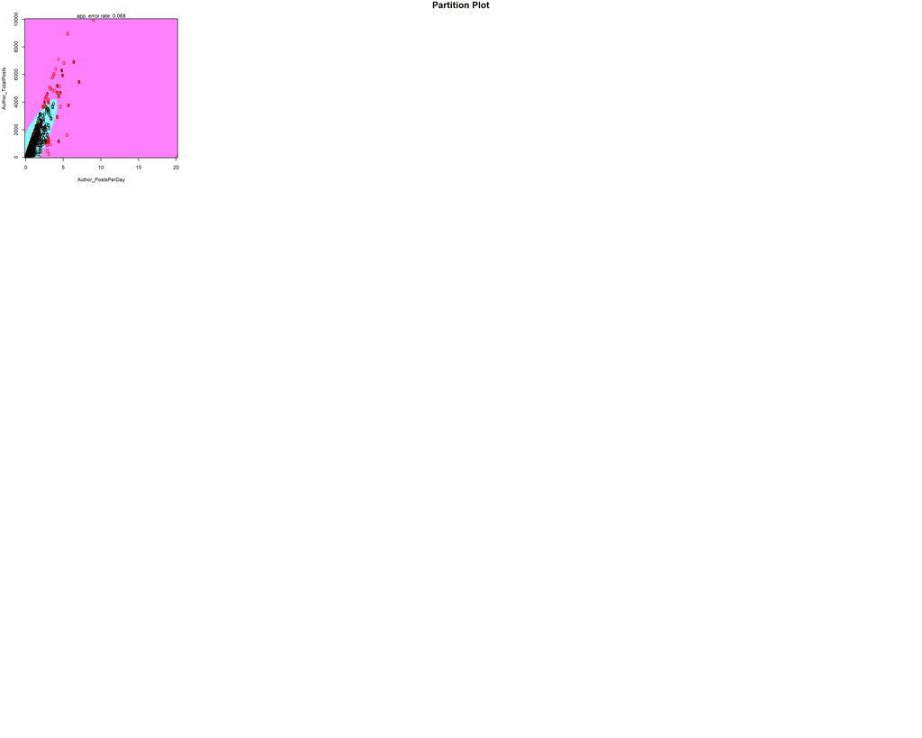

```r
# get bivariate plots showing the LDA decision boundaries
partimat(factor(Recommended) ~ ., data = train, method = "qda")
```

```r
# ROC curve
roc.qda <- roc(as.factor(test$Recommended), pred.qda$posterior[,2])
```

It looks that linear discriminant analysis is doing a little better than quadratic discriminant analysis, but overall not as good as logistic regression or additive logistic regression.

#### KNN

Below is the KNN model we run.

```r
set.seed(1)
ctrl <- trainControl(method="CV", number=10)
suggest.knn <- train(factor(Recommended) ~ ., data = train, method="knn", trControl = ctrl, tuneLength = 20)
suggest.knn
```

```
## k-Nearest Neighbors
##
## 10953 samples
##     7 predictor
##     2 classes: '0', '1'
##
## No pre-processing
## Resampling: Cross-Validated (10 fold)
## Summary of sample sizes: 9858, 9858, 9858, 9858, 9858, 9858, ...
## Resampling results across tuning parameters:
##
##   k   Accuracy   Kappa
##    5  0.9635712  0.25936079
##    7  0.9642102  0.23410438
##    9  0.9651233  0.20701165
##   11  0.9648495  0.17980677
##   13  0.9659450  0.17677837
##   15  0.9664014  0.17481312
##   17  0.9668580  0.18351926
##   19  0.9664932  0.17947736
##   21  0.9659455  0.15499738
##   23  0.9662193  0.14128393
##   25  0.9658543  0.13521516
##   27  0.9660369  0.12873294
##   29  0.9655799  0.11966095
##   31  0.9650322  0.10264537
##   33  0.9653975  0.09556808
##   35  0.9651234  0.08670709
##   37  0.9653975  0.07522170
##   39  0.9651237  0.07016879
##   41  0.9653975  0.07054696
##   43  0.9654890  0.06614296
##
## Accuracy was used to select the optimal model using the largest value.
## The final value used for the model was k = 17.
```

```r
pred.knn <- predict(suggest.knn, newdata = test)

prob.knn <- predict(suggest.knn, newdata = test, type = "prob")[,2]

tab.knn <- confusionMatrix(as.factor(pred.knn), as.factor(test$Recommended), positive = "1")
tab.knn
```

```
## Confusion Matrix and Statistics
##
##           Reference
## Prediction    0    1
##          0 5262  163
##          1   25   26
##
##                Accuracy : 0.9657
##                  95% CI : (0.9605, 0.9703)
##     No Information Rate : 0.9655
##     P-Value [Acc > NIR] : 0.4898
##
##                   Kappa : 0.205
##
##  Mcnemar's Test P-Value : <2e-16
##
##             Sensitivity : 0.137566
##             Specificity : 0.995271
##          Pos Pred Value : 0.509804
##          Neg Pred Value : 0.969954
##              Prevalence : 0.034514
##          Detection Rate : 0.004748
##    Detection Prevalence : 0.009313
##       Balanced Accuracy : 0.566419
##
##        'Positive' Class : 1
##
```

```r
roc.knn = roc(test$Recommended, prob.knn)
```

#### Comparison

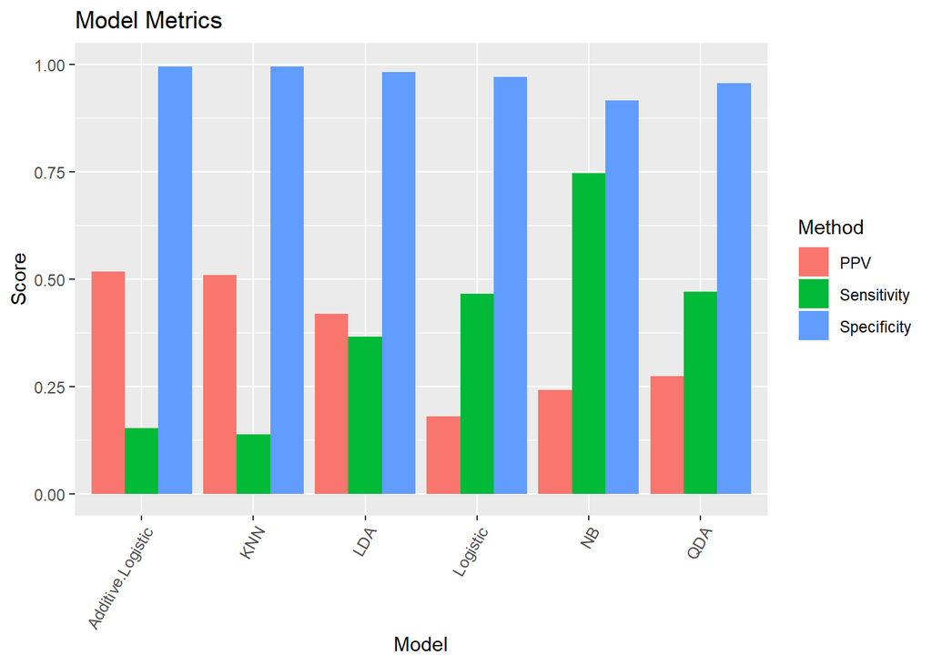

```r
# Source: https://canvas.cmu.edu/courses/29098/files/8114219/download?download_frd=1
performance.metrics <- data.frame("Logistic" = tab.glm$byClass,"Additive Logistic" = tab.gam$byClass,"NB" = tab.nb$byClass,
                                  "LDA" = tab.lda$byClass, "QDA" = tab.qda$byClass, "KNN" = tab.knn$byClass)

performance.metrics <- rbind(performance.metrics, c(roc.glm$auc, roc.gam$auc, roc.nb$auc, roc.lda$auc, roc.qda$auc, roc.knn$auc))
performance.metrics <- t(performance.metrics)
colnames(performance.metrics)[12] <- "AUC"
performance.metrics <- as.data.frame(performance.metrics)
performance.metrics <- performance.metrics %>% dplyr::select("AUC", everything())
performance.metrics <- cbind(performance.metrics, rownames(performance.metrics))
colnames(performance.metrics)[13] <- "Model"

perf.sens <- performance.metrics %>% dplyr::select("Sensitivity", "Model") %>% dplyr::mutate(score = rep("Sensitivity", 6))
perf.spec <- performance.metrics %>% dplyr::select("Specificity", "Model") %>% dplyr::mutate(score = rep("Specificity", 6))
perf.PPV <- performance.metrics %>% dplyr::select("Pos Pred Value", "Model") %>% dplyr::mutate(score = rep("PPV", 6))

colnames(perf.sens) <- c("Score", "Model", "Method")
colnames(perf.spec) <- c("Score", "Model", "Method")
colnames(perf.PPV) <- c("Score", "Model", "Method")


tradeoff.data <- data.frame(rbind(perf.sens, perf.spec, perf.PPV))

# Run for violent and save plot
ggplot(data = tradeoff.data) +
  geom_bar(mapping = aes(x = Model, y = Score, fill = Method),
           position = "dodge", stat = "identity") +
  ylim(c(0,1))+
  theme(axis.text.x = element_text(angle = 60, hjust = 1))+
  ggtitle("Model Metrics")
```

We built our assessment around the following performance metric equations: Sensitivity = TP/(TP + FN) Higher Sensitivity means fewer cases of good suggestions which are predicted as bad. Specificity = TN/(TN + FP) Higher specificity means fewer cases of bad suggestions which are predicted as good. Positive Predictive Value = TP/(TP + FP) Higher PPV represents an improved quality of prediction, with a higher percent of good suggestions predictions being correct.

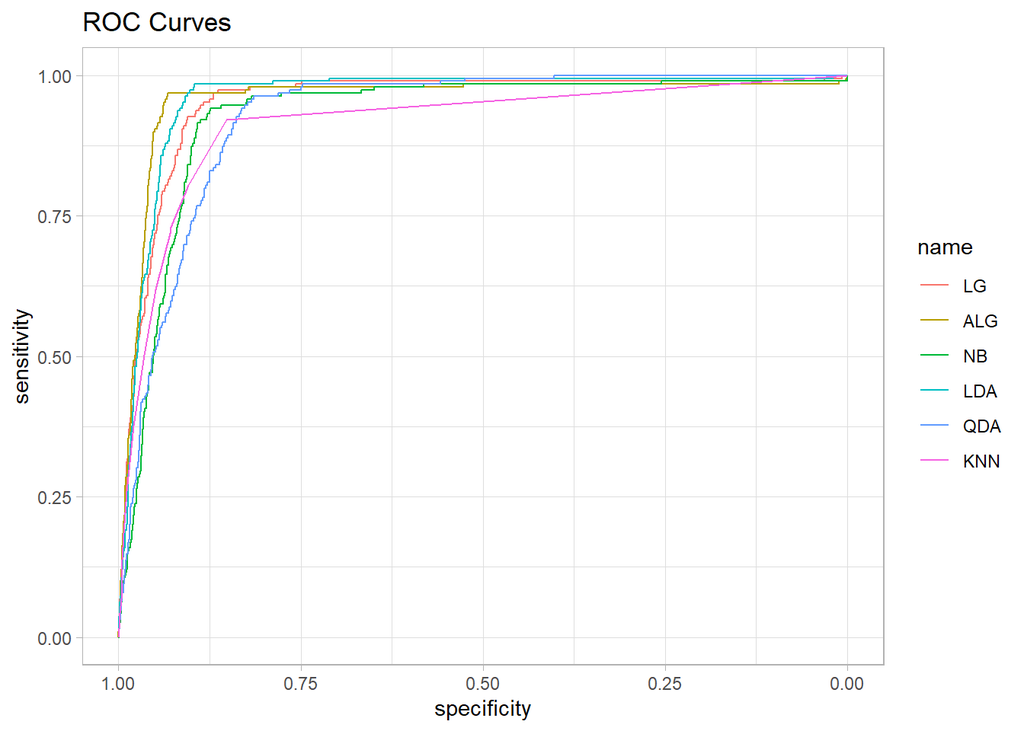

```r
ggroc(list(LG = roc.glm, ALG = roc.gam, NB = roc.nb, LDA = roc.lda, QDA = roc.qda, KNN = roc.knn), ) + theme_light() + ggtitle("ROC Curves")
```

Comparing the ROC curves of each model, although most of our models perform similarly well, we can see the Addictive Logistic Model has really good AUC. That means the model do well in classifying suggestions into good or bad.

The Addictive Logistic Model is following:

```r
# Addictive Logistic Model
summary(suggest.gam)
```

```
##
## Call: gam(formula = Recommended ~ s(Responses, 4) + s(Views, 4) + s(Votes_Up,
##     4) + s(Votes_Down, 4) + s(Author_PostsPerDay, 4), data = train)
## Deviance Residuals:
##        Min         1Q     Median         3Q        Max
## -0.7746697 -0.0210189  0.0001139  0.0068653  1.0003249
##
## (Dispersion Parameter for gaussian family taken to be 0.0221)
##
##     Null Deviance: 360.2976 on 10952 degrees of freedom
## Residual Deviance: 241.1155 on 10932 degrees of freedom
## AIC: -10670.39
##
## Number of Local Scoring Iterations: NA
##
## Anova for Parametric Effects
##                             Df  Sum Sq Mean Sq  F value    Pr(>F)
## s(Responses, 4)              1  22.340 22.3397 1012.863 < 2.2e-16 ***
## s(Views, 4)                  1  10.727 10.7267  486.342 < 2.2e-16 ***
## s(Votes_Up, 4)               1  27.769 27.7686 1259.009 < 2.2e-16 ***
## s(Votes_Down, 4)             1  15.123 15.1228  685.655 < 2.2e-16 ***
## s(Author_PostsPerDay, 4)     1   1.654  1.6540   74.989 < 2.2e-16 ***
## Residuals                10932 241.116  0.0221
## ---
## Signif. codes:  0 '***' 0.001 '**' 0.01 '*' 0.05 '.' 0.1 ' ' 1
##
## Anova for Nonparametric Effects
##                          Npar Df Npar F     Pr(F)
## (Intercept)
## s(Responses, 4)                3  57.66 < 2.2e-16 ***
## s(Views, 4)                    3  26.09 < 2.2e-16 ***
## s(Votes_Up, 4)                 3 637.12 < 2.2e-16 ***
## s(Votes_Down, 4)               3  14.19 3.146e-09 ***
## s(Author_PostsPerDay, 4)       3  14.87 1.175e-09 ***
## ---
## Signif. codes:  0 '***' 0.001 '**' 0.01 '*' 0.05 '.' 0.1 ' ' 1
```

```r
# confusion matrix
tab.gam
```

```
## Confusion Matrix and Statistics
##
##           Reference
## Prediction    0    1
##          0 5260  160
##          1   27   29
##
##                Accuracy : 0.9659
##                  95% CI : (0.9607, 0.9705)
##     No Information Rate : 0.9655
##     P-Value [Acc > NIR] : 0.4603
##
##                   Kappa : 0.2245
##
##  Mcnemar's Test P-Value : <2e-16
##
##             Sensitivity : 0.153439
##             Specificity : 0.994893
##          Pos Pred Value : 0.517857
##          Neg Pred Value : 0.970480
##              Prevalence : 0.034514
##          Detection Rate : 0.005296
##    Detection Prevalence : 0.010226
##       Balanced Accuracy : 0.574166
##
##        'Positive' Class : 1
##
```

Our model has 0.9659 Accuracy in predicting suggestion within test set, we use `Responses`, `Views`, `Votes_Up`, and `Votes_Down`, and `Author_PostsPerDay` to predict if a suggestion is a good one, and all predictors are statistically significant.

### Analysis

#### ‘Age’ of the employee

```r
summary(suggest.glm)
```

```
##
## Call:
## glm(formula = Recommended ~ Responses + Views + Votes_Up + Votes_Down +
##     Author_JoinDays + Author_PostsPerDay, family = "binomial",
##     data = train)
##
## Deviance Residuals:
##     Min       1Q   Median       3Q      Max
## -4.4992  -0.1953  -0.1570  -0.1256   4.2324
##
## Coefficients:
##                      Estimate Std. Error z value Pr(>|z|)
## (Intercept)        -5.417e+00  2.441e-01 -22.191  < 2e-16 ***
## Responses           2.985e-02  2.995e-03   9.966  < 2e-16 ***
## Views               2.329e-04  3.765e-05   6.188 6.11e-10 ***
## Votes_Up            1.282e-02  1.611e-03   7.960 1.73e-15 ***
## Votes_Down         -1.765e-01  1.366e-02 -12.924  < 2e-16 ***
## Author_JoinDays     8.330e-04  1.980e-04   4.208 2.58e-05 ***
## Author_PostsPerDay  3.966e-01  3.338e-02  11.881  < 2e-16 ***
## ---
## Signif. codes:  0 '***' 0.001 '**' 0.01 '*' 0.05 '.' 0.1 ' ' 1
##
## (Dispersion parameter for binomial family taken to be 1)
##
##     Null deviance: 3254.5  on 10952  degrees of freedom
## Residual deviance: 2217.4  on 10946  degrees of freedom
## AIC: 2231.4
##
## Number of Fisher Scoring iterations: 7
```

Compared to other variables, the ‘age’ of the employee seems to not be very important, while the ‘age’ still affects their ability to make a good suggestion.

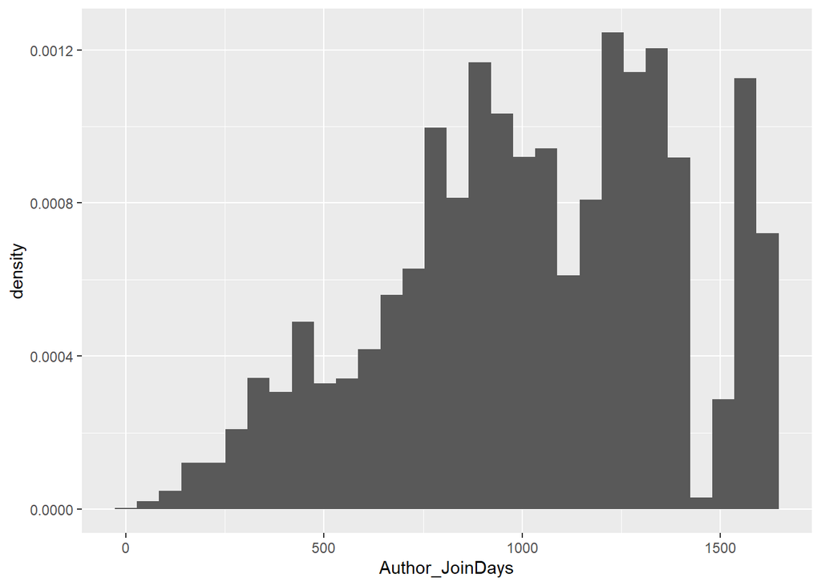

```r
# plot density of Author_JoinDays
ggplot(suggest.subset, aes(x = Author_JoinDays)) + geom_histogram(aes(y=..density..))
```

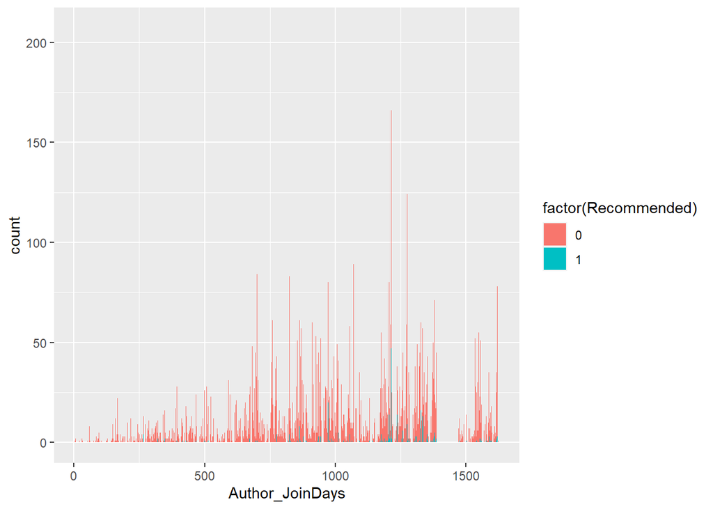

```r
# show how the probability of being a good suggestion varies with 'age'
ggplot(suggest.subset, aes(x = Author_JoinDays, fill = factor(Recommended))) + geom_bar()
```

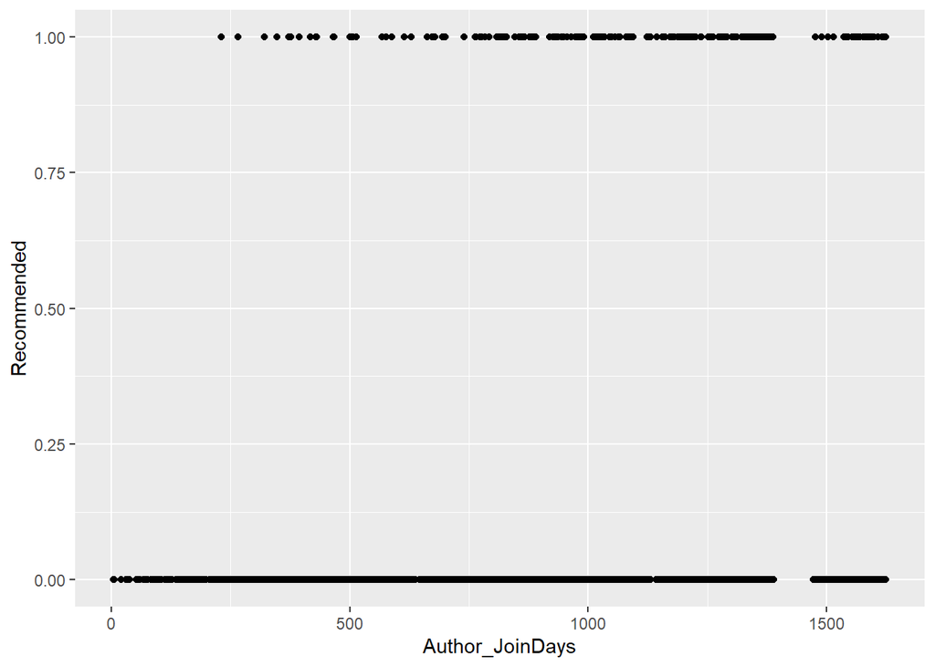

```r
# show the performance of suggestions varies with 'age'
qplot(data = suggest.subset, x = Author_JoinDays, y = Recommended)
```

```r
mean <- (max(suggest.subset$Author_JoinDays) - min(suggest.subset$Author_JoinDays)) / 2

suggestions.longer <- suggest.subset[suggest.subset$Author_JoinDays >= mean ,]
suggestions.shorter <- suggest.subset[suggest.subset$Author_JoinDays < mean ,]

longer.true <- nrow(suggestions.longer[suggestions.longer$Recommended == "1" ,])
longer.false <- nrow(suggestions.longer[suggestions.longer$Recommended == "0" ,])

shorter.true <- nrow(suggestions.shorter[suggestions.shorter$Recommended == "1" ,])
shorter.false <- nrow(suggestions.shorter[suggestions.shorter$Recommended == "0" ,])

# count the recommended suggestions within longer-tenures employees
longer.true
```

```
## [1] 502
```

```r
longer.false
```

```
## [1] 11394
```

```r
longer.rate <- longer.true / (longer.true + longer.false)
longer.rate
```

```
## [1] 0.04219906
```

```r
# count the recommended suggestions within shorter-tenures employees
shorter.true
```

```
## [1] 60
```

```r
shorter.false
```

```
## [1] 4472
```

```r
shorter.rate <- shorter.true / (shorter.true + shorter.false)
shorter.rate
```

```
## [1] 0.01323919
```

#### Rank employees

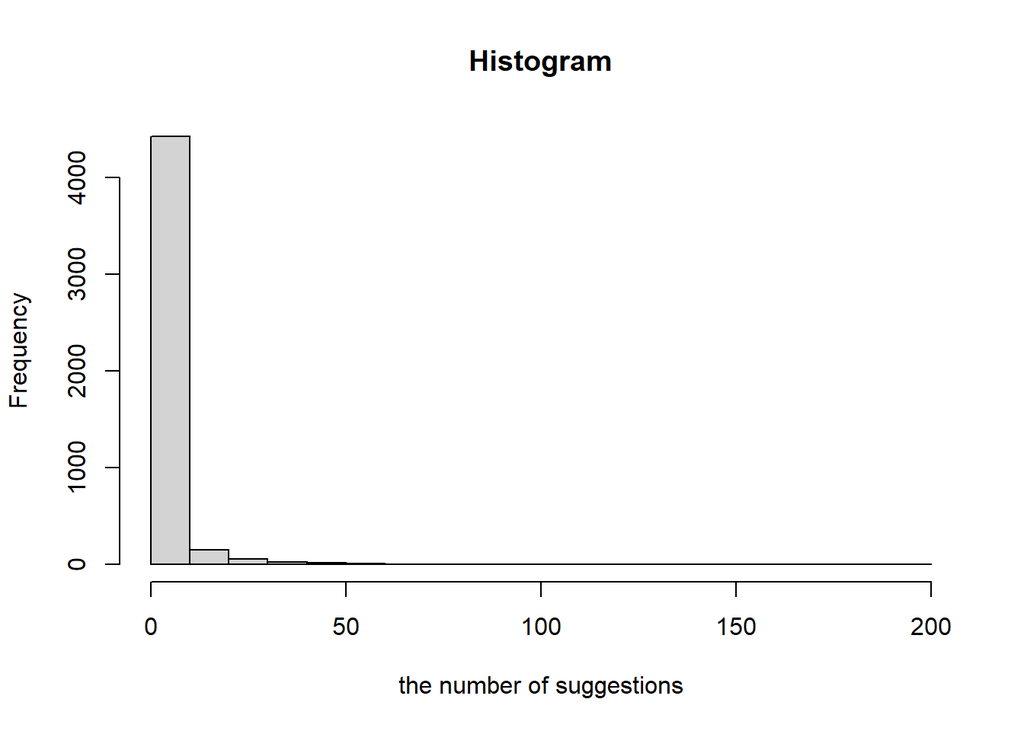

```r
employees <- aggregate(suggest$Suggestion_Id, by=list(suggest$Author_Id),length)
hist(employees$x, xlab = "the number of suggestions", main = "Histogram")
```

From the plot, we can see in this data set most employees just gave suggestions less than 10 times, which means that it is unreasonable to rank these employees using their rate of good suggestions. The number of employees whose numbers of suggestions are more than 10 times is:

```r
nrow(employees[employees$x >= 10,])
```

```
## [1] 308
```

```r
employees.subset <- employees[employees$x >= 10,]
stat <-  aggregate(suggest$Suggestion_Id, by=list(suggest$Author_Id, suggest$Recommended),length)
stat.bad <- rep(308, 0)

# calculate the number of bad suggestions for each employees
for (i in 1:nrow(stat)) {
  for (j in 1:nrow(employees.subset))
  if (stat[i,]$Group.1 == employees.subset[j,]$Group.1) {
    if (stat[i,]$Group.2 == 0) {
       stat.bad[j] <- stat[i,]$x
    }
  }
}
```

```r
# calculate the rank
rate <- stat.bad / employees.subset[,2]
rank <- rank(rate, ties.method = "min")

# sort the rate
sort <- sort(rate)

# create rank table
table.rank <- cbind(employees.subset[,1], rank)

# descending order of rank
table.rank <- table.rank[order(table.rank[,2]),]
table.rank <- data.frame(table.rank)
names(table.rank) <- c("Author_ID", "Rank")

table.rank
```

```
##     Author_ID Rank
## 1      216131    1
## 2      365965    2
## 3      456957    3
## 4       36710    4
## 5      377985    5
## 6      229906    6
## 7      410604    7
## 8     1417861    8
## 9      261495    9
## 10     394835   10
## 11     218675   11
## 12     716219   12
## 13     626791   13
## 14     185450   14
```

[output cut: 294 more lines]

According to the table above, we can rank 308 employees who have enough suggestion records. For those who have few suggestions, we put them into lowest rank. Next, we want to identify if suggestions from groups of employees could be aggregated to provide more reliable suggestions than made by the best individuals.

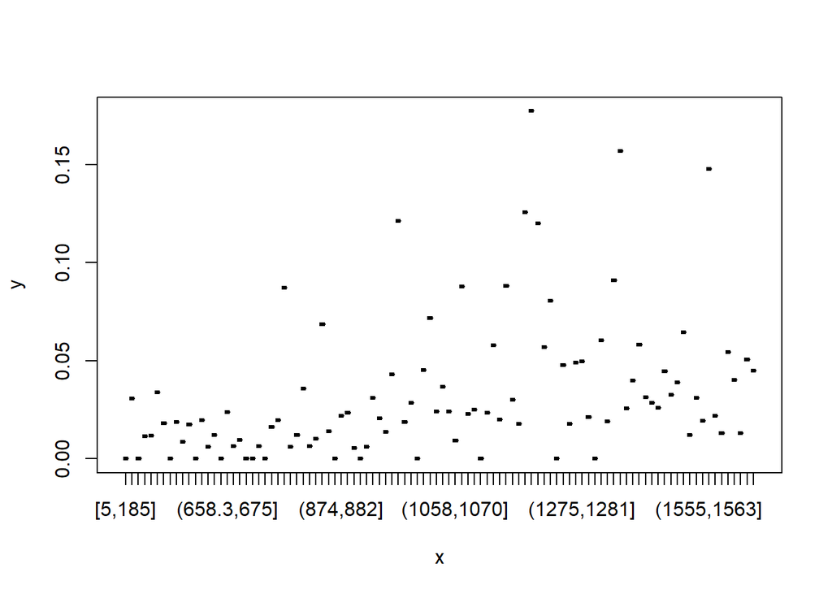

```r
# split employees into 100 groups by their 'ages'
suggest$joinDays.group <- cut_number(suggest$Author_JoinDays, n = 100)
group <- sort(suggest$joinDays.group[!duplicated(suggest$joinDays.group)])

# calculate the rate of good suggestions within each group
group.sum <- aggregate(suggest$Suggestion_Id, by=list(suggest$joinDays.group),length)
group.stat <- aggregate(suggest$Recommended, by=list(suggest$joinDays.group),sum)
group.rate <- group.stat$x / group.sum$x

# plot the rate of each group
plot(group, group.rate)
```

From the plot, we can see the rate of good suggestions for each group, all of rates are relatively small.

```r
# find the group with the highest rate
group[which.max(group.rate)]
```

```
## [1] (1208,1214]
## 100 Levels: [5,185] (185,266.5] (266.5,308] (308,341] (341,369] ... (1619,1624]
```

```r
# compare the max group rate with best individuals
# for 10 best individuals
1 - sort[1:10]
```

```
##  [1] 0.6363636 0.4666667 0.3750000 0.3600000 0.3571429 0.3555556 0.3095238
##  [8] 0.3076923 0.3000000 0.2955975
```

```r
# for best group
max(group.rate)
```

```
## [1] 0.177305
```

We group all employees by their ‘age’, and then compare the rate of good suggestions between these groups and 10 best individuals. We find that it is the groups of employees do not perform better than the best individuals.

### Conclusion and further work

We would recommend the IT department to focus more on certain types of employees or posts when they collect this data. For example, they could leverage more on the suggestions made by employee group which have been with the company from 1180 to 1260 days since they have higher change of making better suggestions. Besides, they could set bonus system to encourage more employees to post on their forum, especially for people who just joined the company. Employee survey can be conducted as well.

Other attributes that may be useful include different topics/categories that these posts belong to, e.g. daily operation, administration and etc. This information will help us better understand what the employees care most about.

From our opinion, it is not impossible to build an automated suggestion ranking system. But how to measure if this system functions well would be something not easy, since suggestions varies a lot and probably change over time, and humans(management) may think strategically different than an automated machine. Therefore, it may be hard to achieve this automated ranking system.

### Our takeaway form this project

This project provides an comprehensive practice from what we learnt from this course. We think model and variable selection are very important in building up good models. Having the domain knowledge will help our analysis.

### Reference

1. https://canvas.cmu.edu/courses/29098/files/8114219?module_item_id=5143803&fd_cookie_set=1